# Predictive models to differentiate between clickbait and non-clickbait headlines.

## Problem Overview

“Clickbait” is online content whose main purpose is to attract attention and encourage visitors to click on a link to a particular web page. The dataset for this assignment consists of clickbait titles (drawn from known clickbait websites such as Buzzfeed) and non-clickbait article titles drawn from reputable sources. The goal of this assignment will be to train predictive models to differentiate between clickbait and non-clickbait headlines.

The goal of this assignment is to get hands-on practice with text featurization, advanced predictive modeling techniques such as Ridge, Lasso, and ensemble methods, and constructing ROC curves.

```r
cb_data <- read_csv("clickbait_headlines.csv") %>%
  mutate(cb_numeric = clickbait,
    clickbait = as.factor(clickbait))
set.seed(1)
train_rows <- sample(nrow(cb_data),.7*nrow(cb_data))
cb_train <- cb_data[train_rows,]
cb_valid <- cb_data[-train_rows,]
```

## 1: Text Featurization

1. Create the clickbait article vocabulary from their titles using the following parameters: lowercase the words, remove numbers and punctuation, remove stopwords, perform stemming. Include both unigrams and bigrams. Prune the resulting vocabulary to only include terms that occur in at least 10 article titles.

**ANSWER TO QUESTION 1a HERE:**

```r
#Steps 1 and 2: preprocess and tokenize
cleaning_tokenizer <- function(v) {
  v %>%
    removeNumbers %>%
    removePunctuation %>%
    removeWords(tm::stopwords(kind="en"))%>%
    stemDocument %>%
    word_tokenizer
}

it_train <- itoken(cb_train$article_title,
                   preprocessor = tolower,
                   tokenizer = cleaning_tokenizer,
                   ids = cb_train$article_id,
                   progressbar = FALSE)

it_valid <-itoken(cb_valid$article_title,
                   preprocessor = tolower,
                   tokenizer = cleaning_tokenizer,
                   ids = cb_valid$article_id,
                   progressbar = FALSE)

# Step 3: create the vocabulary
vocab_train <- create_vocabulary(it_train)

#Include ngrams
vocab2 <- create_vocabulary(it_train,ngram = c(1L, 2L))

vocab_final <- prune_vocabulary(vocab2, term_count_min = 10, doc_proportion_max = 0.5)
```

2. Vectorize the training and validation emails to complete your BOW representation.

**ANSWER TO QUESTION 1b HERE:**

```r
vectorizer <- vocab_vectorizer(vocab_final)
# Convert the training documents into a DTM
dtm_train <- create_dtm(it_train, vectorizer)
dtm_valid <- create_dtm(it_valid, vectorizer)
dim(dtm_train)
```

```
## [1] 7000 1079
```

```r
dim(dtm_valid)
```

```
## [1] 3000 1079
```

```r
#BOW representation:replace terms with count greater than 0 with just 1
dtm_train_bin <- dtm_train
dtm_train_bin[dtm_train_bin > 0] <- 1

dtm_valid_bin <- dtm_valid
dtm_valid_bin[dtm_valid_bin > 0] <- 1
```

3. Count the number of positive and negative terms in each title in the training using the “Bing” sentiment dictionary. On average, which type of content has a more “positive” sentiment: clickbait or nonclickbait titles?

**ANSWER TO QUESTION 1c HERE:**

**Clickbait content has more positive sebtiment.**

```r
get_sentiments("bing")
```

| word | sentiment |
| --- | --- |
| 2-faces | negative |
| abnormal | negative |
| abolish | negative |
| abominable | negative |
| abominably | negative |
| abominate | negative |
| abomination | negative |
| abort | negative |
| aborted | negative |
| aborts | negative |

[output cut: 6776 more lines]

```r
bing_negative <- get_sentiments("bing") %>%
  filter(sentiment == 'negative')

bing_positive <- get_sentiments("bing") %>%
  filter(sentiment == 'positive')

# Construct the dictionary
mydict <- dictionary(list(negative = bing_negative$word, positive = bing_positive$word))
tr_dfm <- as.dfm(dtm_train)
# how does dfm look like? it's basically the same thing as dtm
tr_dfm
```

```
## Document-feature matrix of: 7,000 documents, 1,079 features (99.63% sparse) and 0 docvars.
##        features
## docs    act activist adam admit africa alert alway amazon angel apolog
##   27866   0        0    0     0      0     0     0      0     0      0
##   19344   0        0    0     0      0     0     0      0     0      0
##   7372    0        0    0     0      0     0     0      0     0      0
##   12040   0        0    0     0      0     0     0      0     0      0
##   15373   0        0    0     0      0     0     0      0     0      0
##   2595    0        0    0     0      0     0     0      0     0      0
## [ reached max_ndoc ... 6,994 more documents, reached max_nfeat ... 1,069 more features ]
```

```r
sentiments <- dfm_lookup(tr_dfm, mydict, valuetype = 'fixed')
sentiments
```

```
## Document-feature matrix of: 7,000 documents, 2 features (81.95% sparse) and 0 docvars.
##        features
## docs    negative positive
##   27866        0        0
##   19344        0        0
##   7372         0        0
##   12040        0        1
##   15373        0        1
##   2595         0        0
## [ reached max_ndoc ... 6,994 more documents ]
```

```r
# Convert the sentiments to a data frame
sentiments <- convert(sentiments, to = "data.frame") %>%
  mutate(sent_score = as.factor(ifelse(positive >= negative, 'P', 'N')))
# Add the clickbait indicator to the sentiments data frame
sentiments$clickbait <- cb_train$clickbait

average_sentiment <- sentiments %>%
  group_by(clickbait) %>%
  summarise(average_positive = mean(positive), average_negative = mean(negative))

average_sentiment
```

| clickbait | average_positive | average_negative |
| --- | --- | --- |
| 0 | 0.1008919 | 0.3235786 |
| 1 | 0.2458968 | 0.1471278 |

## 2: Ridge and Lasso

Your goal going forward is to predict the “clickbait” target variable using a few different types of models. You’ll compare them to pick the best-performing model in terms of validation AUC.

1. Using a grid of 100 lambda values ranging between 10^-7 and 10^7, find the optimal lambda for a Ridge-penalized logistic regression model. Plot the fitting curve and report the optimal lambda. (optionally, you can use cv.glmnet with k = 5 if you want)

Make predictions with your best lambda ridge model and store them as a variable called preds_ridge.

**ANSWER TO QUESTION 2a HERE:**

```r
# define a function to calculate accuracy
accuracy <- function(classifications, actuals){
  correct_classifications <- ifelse(classifications == actuals, 1, 0)
  acc <- sum(correct_classifications)/length(classifications)
  return(acc)
}

dtm_train<- as.matrix(dtm_train)
dtm_valid <- as.matrix(dtm_valid)

# Extract the 'clickbait' column
tr_y <- cb_train$clickbait
va_y <- cb_valid$clickbait


grid <- 10^seq(-7,7,length=100)

accs <- rep(0, length(grid))

for(i in c(1:length(grid))){
  lam = grid[i] #current value of lambda

  #train a ridge model with lambda = lam
  glmout <- glmnet(dtm_train, tr_y, family = "binomial", alpha = 0, lambda = lam)

  #make predictions as usual
  preds <- predict(glmout, newx = dtm_valid, type = "response")

  #classify and compute accuracy
  classifications <- ifelse(preds > .5, "YES", "NO")
  inner_acc <- accuracy(classifications, va_y)
  accs[i] <- inner_acc
}

# get best-performing lambda
best_validation_index <- which.max(accs)
best_lambda <- grid[best_validation_index]
best_lambda
```

```
## [1] 1e-07
```

```r
# Train a ridge model with the best lambda
best_glmout <- glmnet(dtm_train, tr_y, family = "binomial", alpha = 0, lambda = best_lambda)

# Make predictions
preds_ridge <- predict(best_glmout, newx = dtm_valid, type = "response")
```

2. Repeat part (a) for a Lasso-penalized logistic regression model. Store the predictions from your best model in a variable called preds_lasso.

**ANSWER TO QUESTION 2b HERE:**

```r
grid <- 10^seq(-7,7,length=100)

accs <- rep(0, length(grid))

for(i in c(1:length(grid))){
  lam = grid[i] #current value of lambda

  #train a ridge model with lambda = lam
  glmout <- glmnet(dtm_train, tr_y, family = "binomial", alpha = 1, lambda = lam)

  #make predictions as usual
  preds <- predict(glmout, newx = dtm_valid, type = "response")

  #classify and compute accuracy
  classifications <- ifelse(preds > .5, "YES", "NO")
  inner_acc <- accuracy(classifications, va_y)
  accs[i] <- inner_acc
}

# get best-performing lambda
best_validation_index_lasso <- which.max(accs)
best_lambda_lasso <- grid[best_validation_index]
best_lambda_lasso
```

```
## [1] 1e-07
```

```r
# Train a ridge model with the best lambda
best_glmout_lasso <- glmnet(dtm_train, tr_y, family = "binomial", alpha = 1, lambda = best_lambda_lasso)

# Make predictions
preds_lasso <- predict(best_glmout_lasso, newx = dtm_valid, type = "response")
```

3. Do the ridge and lasso models have the same best lambda? Will the two models have identical coefficients? Which has better validation AUC?

```r
# Compute the AUC for the Ridge model
pred_ridge <- prediction(preds_ridge, va_y)
perf_ridge <- performance(pred_ridge, "auc")
auc_ridge <- perf_ridge@y.values[[1]]

# Compute the AUC for the Lasso model
pred_lasso <- prediction(preds_lasso, va_y)
perf_lasso <- performance(pred_lasso, "auc")
auc_lasso <- perf_lasso@y.values[[1]]

# Compare the AUCs
print(paste("Ridge AUC: ", auc_ridge,",and Lasso AUC: ", auc_lasso))
```

```
## [1] "Ridge AUC:  0.952080802079202 ,and Lasso AUC:  0.95197673529145"
```

## 3: Ensemble Methods

1. Use ranger() to train a random forest model with 500 trees and m = 15. (Be patient, this one takes a few minutes to run). Estimate predictions in the validation set and report the AUC. Create a variable importance plot. Which are the most important terms?

Store predictions from your random forest model as preds_rf.

**ANSWER TO QUESTION 3a HERE:** **The top 3 important terms are thing, people and know.**

```r
rf.mod <- ranger(x = dtm_train, y = tr_y,
                 mtry=15, num.trees=500,
                 importance="impurity",
                 probability = TRUE)

preds_rf <- predict(rf.mod, data=dtm_valid)$predictions

preds_rf <- preds_rf[,2]
rf_classifications <- ifelse(preds_rf>0.5, "P", "N")
rf_accuracy <- mean(ifelse(rf_classifications == va_y, 1, 0))

# Create a prediction object
pred_obj <- prediction(preds_rf, va_y)

# Compute the AUC
perf_obj <- performance(pred_obj, measure = "auc")
auc_ranger <- perf_obj@y.values[[1]]

# Print the AUC
print(paste("Random Forest AUC: ", auc_ranger))
```

```
## [1] "Random Forest AUC:  0.964457189413983"
```

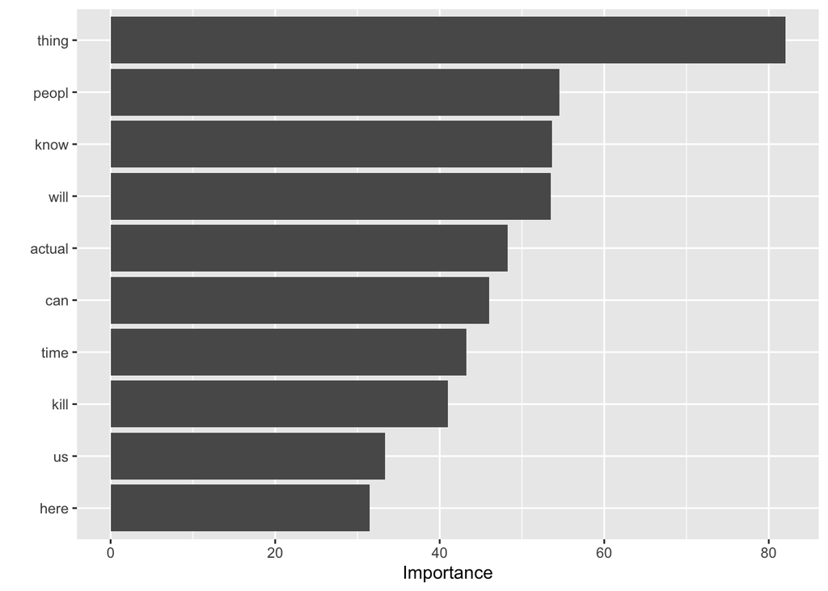

```r
#Which are the most important terms?
vip(rf.mod)
```

2. Use xgboost() to train a boosting model with max.depth = 10, eta = 1, and nrounds = 2500. Estimate predictions in the validation set and report the AUC. Create another variable importance plot. Are the most important terms the same as for the random forest model?

Store predictions from your boosting model as preds_bst.

**ANSWER TO QUESTION 3b HERE:** **The most important terms of boosting model are almost the same as for the random forest model. But the importance scores are different in two models.**

```r
tr_y_num <- as.numeric(cb_train$clickbait)-1
va_y_num <- as.numeric(cb_valid$clickbait)-1

bst <- xgboost(data = dtm_train,
               label = tr_y_num,
               max.depth = 10,
               eta = 1,
               nrounds = 2500,
               objective = "binary:logistic")
preds_bst <- predict(bst, dtm_valid)
bst_classifications <- ifelse(preds_bst > 0.5, 1, 0)
bst_accuracy <- mean(ifelse(bst_classifications == va_y_num, 1, 0))
paste('Accuracy of the boosting based method is:', bst_accuracy)
```

```
## [1] "Accuracy of the boosting based method is: 0.904666666666667"
```

```r
# Create a prediction object
pred_obj_b <- prediction(preds_bst, va_y_num)

# Compute the AUC
perf_obj_b <- performance(pred_obj_b, measure = "auc")
auc_bst <- perf_obj_b@y.values[[1]]

# Print the AUC
print(paste("Boosting AUC: ", auc_bst))
```

```
## [1] "Boosting AUC:  0.962465911456054"
```

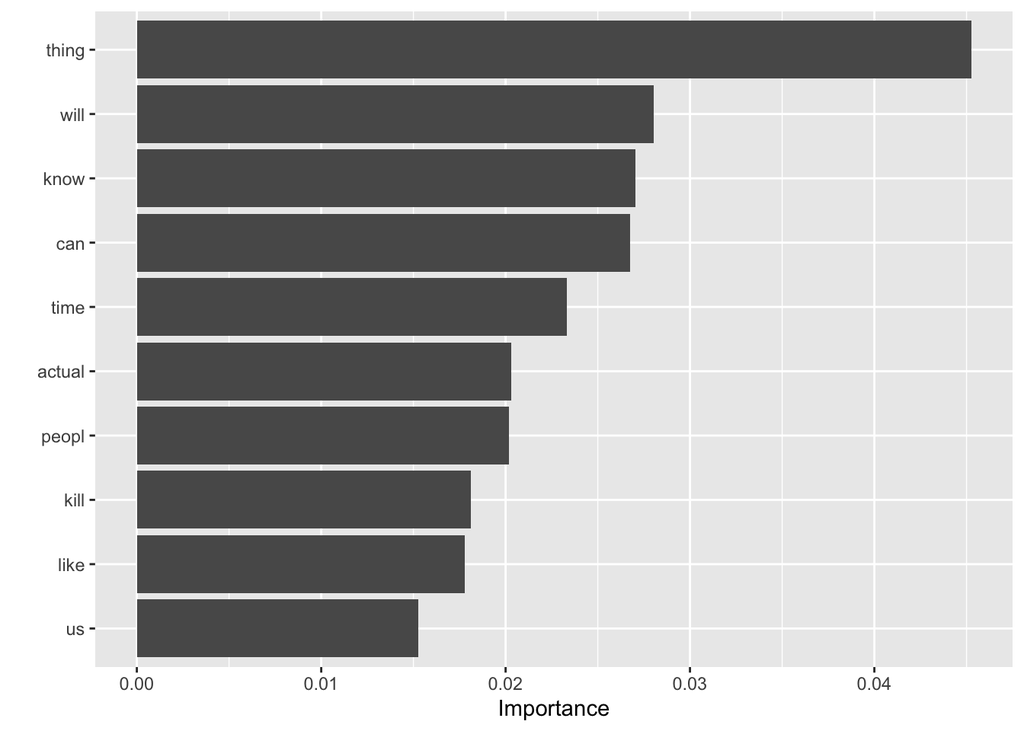

```r
vip(bst)
```

## 4: ROC and Misclassification Analysis

1. Create an ROC plot including ROC curves for your best ridge, best lasso, random forest, and boosted models. Make sure to depict them using different colors. Is the highest-AUC model consistently the best, across all FPR values?

**ANSWER TO QUESTION 4a HERE:** **When the FPR values are lower than 0.3, the random forest and boosting model have the higher AUC, however, when FPR values are higher than 0.3, the AUC of four models are almost the same.Thus, the higher-AUC model is not consistently the best.**

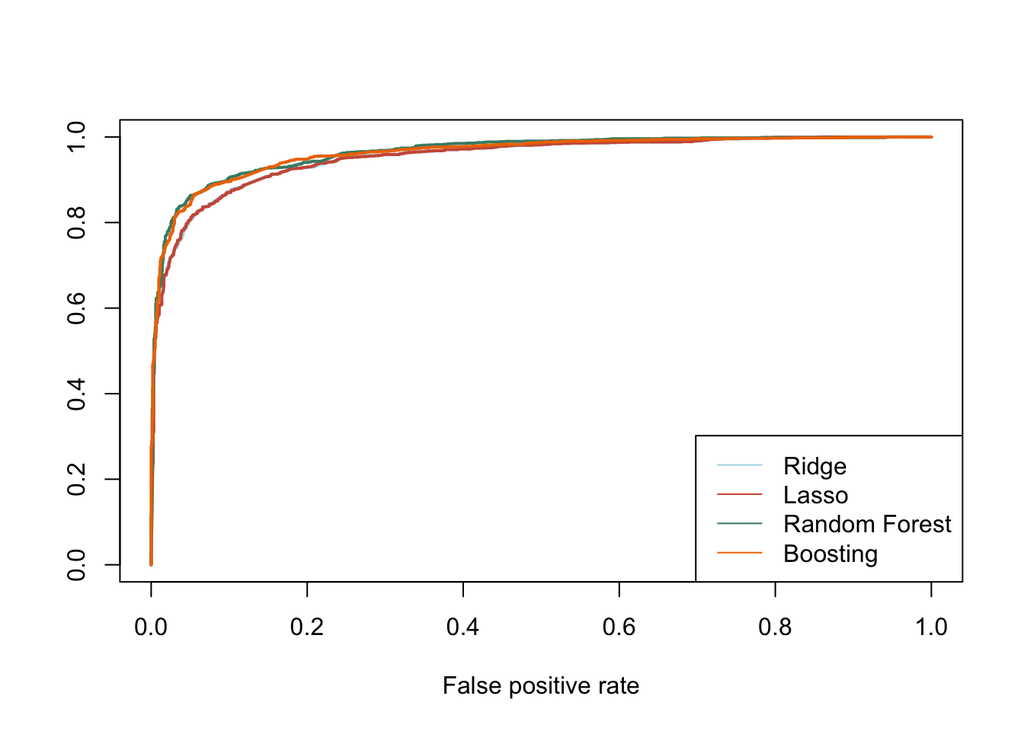

```r
pred_obj_ridge <- prediction(preds_ridge, va_y_num)
pred_obj_lasso <- prediction(preds_lasso, va_y)
pred_obj_rf <- prediction(preds_rf, va_y_num)
pred_obj_bst <- prediction(preds_bst, va_y_num)

# Compute performance measures
perf_ridge_roc <- performance(pred_obj_ridge, "tpr", "fpr")
perf_lasso_roc <- performance(pred_obj_lasso , "tpr", "fpr")
perf_rf_roc <- performance(pred_obj_rf, "tpr", "fpr")
perf_bst_roc <- performance(pred_obj_bst, "tpr", "fpr")

# Plot ROC curves
plot(perf_ridge_roc, col = "lightblue",ylab = '', lwd=2,xlim = c(0, 1), ylim = c(0, 1))
roc_plot <- recordPlot()

replayPlot(roc_plot)
plot(perf_lasso_roc, add=TRUE, col = "coral3",ylab = '', lwd=2)
roc_plot <- recordPlot()

replayPlot(roc_plot)
plot(perf_rf_roc, add=TRUE, col = "aquamarine4",ylab = '', lwd=2)
roc_plot <- recordPlot()

replayPlot(roc_plot)
plot(perf_bst_roc, add=TRUE, col = "darkorange2",ylab = '', lwd=2)

# Add legend
legend("bottomright", legend = c("Ridge", "Lasso", "Random Forest", "Boosting"),
       col = c("lightblue", "coral3", "aquamarine4", "darkorange2"), lty = 1)
```

2. Make classifications using the predictions from your ridge model and a cutoff of 0.5. Inspect some of the misclassifications. Find two false positives and two false negatives and explain why you think they may have been misclassified.

**ANSWER TO QUESTION 4b HERE:**

```r
classifications_ridge = ifelse(preds_ridge >= 0.5, 1, 0)

# Find false positives and false negatives
false_positives = which(classifications_ridge == 1 & va_y == 0)
false_negatives = which(classifications_ridge == 0 & va_y == 1)

# Get two false positives and two false negatives
two_false_positives_title = cb_valid[false_positives[1:2], "article_title"]
two_false_negatives_title = cb_valid[false_negatives[1:2], "article_title"]

two_false_positives_title
```

| article_title |
| --- |
| Unlikely 1-2 Finish for Brawn Team in Formula One Season Opener |
| CanadaVOTES: Animal Alliance (AAEVPC) candidate Marie Crawford running in Toronto—Danforth |

```r
two_false_negatives_title
```

| article_title |
| --- |
| The Trailer For Star Trek Beyond Shows Us A New Villain |
| A Quick Shout-Out To Lupita Nyong'o's Umbrella Man |

## 5: Variable Selection

1. Re-tokenize the article titles using the following parameters: DON’T remove numbers, DON’T remove punctuation, DON’T remove stop words, and DON’T stem the document. Create the vocabulary, including up to 4-grams. DON’T prune the vocabulary (yet). How many terms end up in the vocabulary?

**ANSWER TO QUESTION 5a HERE:**

**41104 terms end up in the vacabulary**

```r
#Steps 1 and 2: preprocess and tokenize
cleaning_tokenizer_new <- function(v) {
  v %>%
    word_tokenizer
}

it_train_new <- itoken(cb_train$article_title,
                   preprocessor = tolower,
                   tokenizer = cleaning_tokenizer_new,
                   ids = cb_train$article_id,
                   progressbar = FALSE)

# Step 3: create the vocabulary
vocab_train_new <- create_vocabulary(it_train_new)

#Include ngrams
vocab2_new <- create_vocabulary(it_train_new,ngram = c(4,4))
```

2. Using your best-lambda Ridge model, make a plot showing the effect of vocabulary size on validation accuracy. What is the effect of vocabulary size on predictive performance? Does it appear that including “too many terms” will cause the model to overfit?

Hint: try pruning the vocabulary using a range of max_vocab_size values from 10 to the total size of the vocabulary (you don’t have to try every single size). Create a list of your vocabulary sizes and loop over each size. You will have to re-vectorize the training and validation data before training each a new model. Plot the log of the resulting vocabulary size vs. validation AUC.

```r
it_valid_new <-itoken(cb_valid$article_title,
                   preprocessor = tolower,
                   tokenizer = cleaning_tokenizer_new,
                   ids = cb_valid$article_id,
                   progressbar = FALSE)

# Initialize vector to store validation accuracies
auc_r <- c()
val_accs <- c()

# Range of vocabulary sizes
vocab_sizes <- seq(10, nrow(vocab2_new), by = 100)

for (vocab_size in vocab_sizes) {
  print(paste("Processing vocab_size:", vocab_size))
  # Prune vocabulary
  pruned_vocab <- vocab2_new[1:vocab_size, ]

  # Create a vectorizer with the pruned vocabulary
  vectorizer <- vocab_vectorizer(pruned_vocab)

  # Vectorize training and validation data
  dtm_train <- create_dtm(it_train_new, vectorizer)
  dtm_val <- create_dtm(it_valid_new, vectorizer)

  print(dim(dtm_train))
  print(dim(dtm_val))

  # Train Ridge model
  model <- glmnet(dtm_train, tr_y_num, alpha = 0, lambda = best_lambda)

  # Compute validation accuracy
  preds <- predict(model, newx = dtm_val)
  val_acc <- sum((preds >= 0.5) == va_y_num) / length(va_y_num)

  # Store validation accuracy
  val_accs <- c(val_accs, val_acc)

  # Create a prediction object
  pred_obj_r <- prediction(preds, va_y_num)

  # Compute the AUC
  perf_obj_r <- performance(pred_obj_r, measure = "auc")
  auc_r <- c(auc_r, perf_obj_r@y.values[[1]])
  print(paste("Current length of auc_r:", length(auc_r)))
}
```

```
## [1] "Processing vocab_size: 10"
```

```
## [1] 7000   10
## [1] 3000   10
## [1] "Current length of auc_r: 1"
## [1] "Processing vocab_size: 110"
```

```
## [1] 7000  110
## [1] 3000  110
## [1] "Current length of auc_r: 2"
## [1] "Processing vocab_size: 210"
```

```
## [1] 7000  210
## [1] 3000  210
## [1] "Current length of auc_r: 3"
## [1] "Processing vocab_size: 310"
```

```
## [1] 7000  310
## [1] 3000  310
## [1] "Current length of auc_r: 4"
## [1] "Processing vocab_size: 410"
## [1] 7000  410
## [1] 3000  410
## [1] "Current length of auc_r: 5"
## [1] "Processing vocab_size: 510"
## [1] 7000  510
## [1] 3000  510
## [1] "Current length of auc_r: 6"
## [1] "Processing vocab_size: 610"
## [1] 7000  610
## [1] 3000  610
## [1] "Current length of auc_r: 7"
```

[output cut: 1616 more lines]

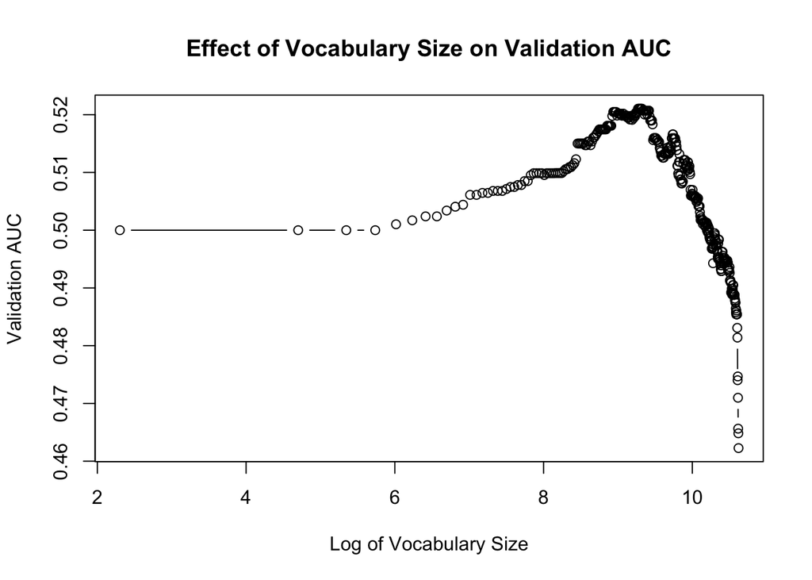

```r
# Plot log of vocabulary size vs. validation accuracy
plot(log(vocab_sizes), auc_r, type = "b",
     xlab = "Log of Vocabulary Size", ylab = "Validation AUC",
     main = "Effect of Vocabulary Size on Validation AUC")
```